# 4_abq_ml_exploration_time_freq

1 Ground predictions

1.1 PVLib Clearsky

2 Train/test on NSRDB data to find optimal parameters

3 Train on all NSRDB data, test various freq of ground data

3.1 30 min freq ground data

3.2 15 min freq ground data

3.3 10 min freq ground data

3.4 5 min freq ground data

3.5 1 min freq ground data

4 Save model

5 Conclusion

```python
import pandas as pd
import numpy as np
import os
import datetime
import matplotlib
import matplotlib.pyplot as plt
from mpl_toolkits.axes_grid1 import make_axes_locatable
from sklearn import tree

import pytz
import itertools
import visualize
import utils
import pydotplus
import xgboost as xgb

from sklearn import metrics
from sklearn import model_selection

import pvlib
import cs_detection

import visualize_plotly as visualize
from plotly.offline import download_plotlyjs, init_notebook_mode, plot, iplot
import plotly.graph_objs as go
init_notebook_mode(connected=True)

from IPython.display import Image

%load_ext autoreload
%autoreload 2

np.set_printoptions(precision=4)
%matplotlib notebook
```

```
The autoreload extension is already loaded. To reload it, use:
  %reload_ext autoreload
```

# Ground predictions

## PVLib Clearsky

Only making ground predictions using PVLib clearsky model and statistical model. NSRDB model won't be available to ground measurements.

```python
nsrdb = cs_detection.ClearskyDetection.read_pickle('abq_nsrdb_1.pkl.gz')
nsrdb.df.index = nsrdb.df.index.tz_convert('MST')
```

nsrdb.trim_dates('01-01-2014', '01-01-2016')

```python
nsrdb.time_from_solar_noon('Clearsky GHI pvlib', 'tfn')
```

```python
ground = cs_detection.ClearskyDetection.read_pickle('abq_ground_1.pkl.gz')
ground.df.index = ground.df.index.tz_convert('MST')
```

```python
feature_cols = [
'tfn',
'abs_ideal_ratio_diff',
'abs_ideal_ratio_diff mean',
'abs_ideal_ratio_diff std',
'GHI Clearsky GHI pvlib gradient ratio',
'GHI Clearsky GHI pvlib gradient ratio mean',
'GHI Clearsky GHI pvlib gradient ratio std',
'GHI Clearsky GHI pvlib gradient second ratio',
'GHI Clearsky GHI pvlib gradient second ratio mean',
'GHI Clearsky GHI pvlib gradient second ratio std',
'GHI Clearsky GHI pvlib line length ratio',
'GHI Clearsky GHI pvlib line length ratio gradient',
'GHI Clearsky GHI pvlib line length ratio gradient second'
]

target_cols = ['sky_status']
```

# Train/test on NSRDB data to find optimal parameters

```python
train = cs_detection.ClearskyDetection(nsrdb.df)
train.trim_dates('01-01-2010', '06-01-2015')
test = cs_detection.ClearskyDetection(nsrdb.df)
test.trim_dates('06-01-2015', None)
```

```python
train.scale_model('GHI', 'Clearsky GHI pvlib', 'sky_status')
```

```python
utils.calc_all_window_metrics(train.df, 3, meas_col='GHI', model_col='Clearsky GHI pvlib', overwrite=True)
```

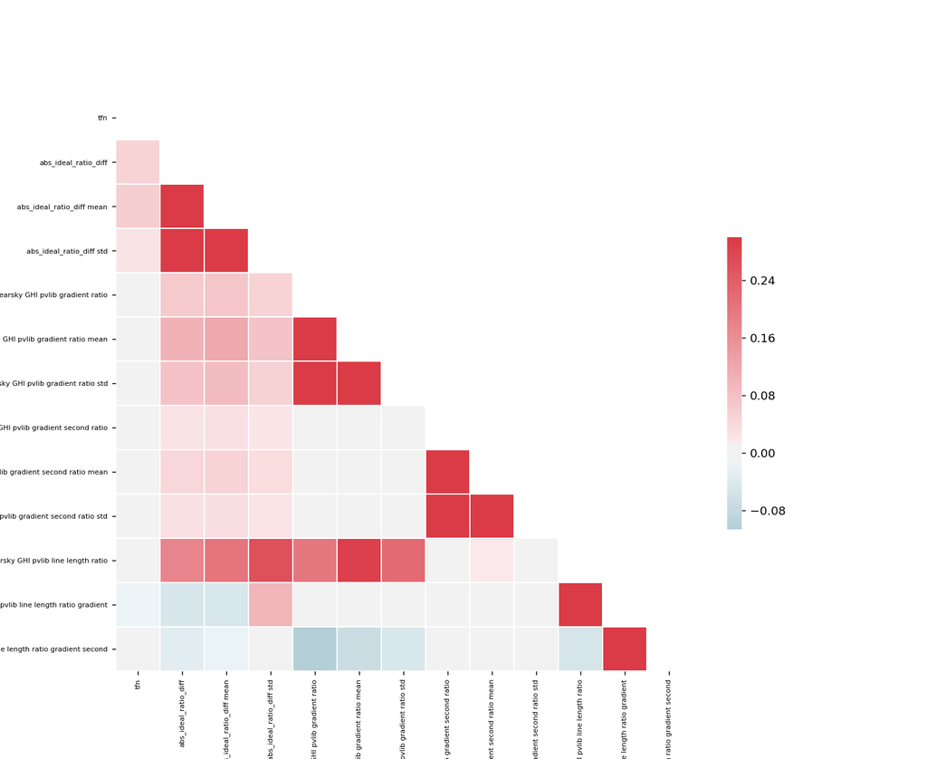

```python
vis = visualize.Visualizer()
vis.plot_corr_matrix(train.df[feature_cols].corr().values, labels=feature_cols)
```

```python
param_grid = {'max_depth': [3, 4], 'n_estimators': [200, 400], 'learning_rate': [.1, .01]}
```

```python
import itertools
import warnings
best_score = 0
best_params = {}
with warnings.catch_warnings():
    warnings.simplefilter('ignore')
    for depth, n_est, lr in itertools.product(param_grid['max_depth'], param_grid['n_estimators'], param_grid['learning_rate']):
        clf = xgb.XGBClassifier(max_depth=depth, n_estimators=n_est, learning_rate=lr, n_jobs=4)
        clf.fit(train.df[feature_cols].values, train.df[target_cols].values.flatten())
        test = cs_detection.ClearskyDetection(nsrdb.df)
        test.trim_dates('06-01-2015', None)
        pred = test.iter_predict_daily(feature_cols, 'GHI', 'Clearsky GHI pvlib', clf, 3, multiproc=False)
        score = metrics.f1_score(test.df['sky_status'], pred)
        # score = metrics.precision_score(test.df['sky_status'], pred)
        indicator = ''
        if score > best_score:
            best_score = score
            best_params['max_depth'] = depth
            best_params['n_estimators'] = n_est
            best_params['learnin_rate'] = lr
            indicator = '*'
        print('max_depth: {}, n_estimators: {}, learning_rate: {}, accuracy: {} {}'.format(depth, n_est, lr, score, indicator))
```

```
max_depth: 3, n_estimators: 200, learning_rate: 0.1, accuracy: 0.9103955197759888 *
max_depth: 3, n_estimators: 200, learning_rate: 0.01, accuracy: 0.9116438356164384 *
max_depth: 3, n_estimators: 400, learning_rate: 0.1, accuracy: 0.911707916447253 *
max_depth: 3, n_estimators: 400, learning_rate: 0.01, accuracy: 0.9106427451663474
max_depth: 4, n_estimators: 200, learning_rate: 0.1, accuracy: 0.9117647058823529 *
max_depth: 4, n_estimators: 200, learning_rate: 0.01, accuracy: 0.9098862642169728
max_depth: 4, n_estimators: 400, learning_rate: 0.1, accuracy: 0.9129139653057649 *
max_depth: 4, n_estimators: 400, learning_rate: 0.01, accuracy: 0.9115028800837842
```

```python
clf = xgb.XGBClassifier(**best_params, n_jobs=4)
clf.fit(train.df[feature_cols].values, train.df[target_cols].values.flatten())
```

```
XGBClassifier(base_score=0.5, booster='gbtree', colsample_bylevel=1,
       colsample_bytree=1, gamma=0, learnin_rate=0.1, learning_rate=0.1,
       max_delta_step=0, max_depth=4, min_child_weight=1, missing=None,
       n_estimators=400, n_jobs=4, nthread=None,
       objective='binary:logistic', random_state=0, reg_alpha=0,
       reg_lambda=1, scale_pos_weight=1, seed=None, silent=True,
       subsample=1)
```

```python
test = cs_detection.ClearskyDetection(nsrdb.df)
test.trim_dates('06-01-2015', None)
```

```python
%%time
pred = test.iter_predict_daily(feature_cols, 'GHI', 'Clearsky GHI pvlib', clf, 3, multiproc=False).astype(bool)
```

```
CPU times: user 3.54 s, sys: 31 ms, total: 3.57 s
Wall time: 3 s
```

```python
vis = visualize.Visualizer()
vis.add_line_ser(test.df['GHI'], 'GHI')
vis.add_line_ser(test.df['Clearsky GHI pvlib'], 'GHI_cs')
vis.add_circle_ser(test.df[(test.df['sky_status'] == 0) & (pred)]['GHI'], 'ML clear only')
vis.add_circle_ser(test.df[(test.df['sky_status'] == 1) & (~pred)]['GHI'], 'NSRDB clear only')
vis.add_circle_ser(test.df[(test.df['sky_status'] == 1) & (pred)]['GHI'], 'ML+NSRDB clear only')
vis.show()
```

[interactive chart not shown]

```python
cm = metrics.confusion_matrix(test.df['sky_status'].values, pred)
vis = visualize.Visualizer()
vis.plot_confusion_matrix(cm, labels=['cloudy', 'clear'])
```

[interactive chart not shown]

```python
print(metrics.f1_score(test.df['sky_status'].values, pred))
```

```
0.915105898827
```

# Train on all NSRDB data, test various freq of ground data

```python
train = cs_detection.ClearskyDetection(nsrdb.df)
train.scale_model('GHI', 'Clearsky GHI pvlib', 'sky_status')
utils.calc_all_window_metrics(train.df, 3, meas_col='GHI', model_col='Clearsky GHI pvlib', overwrite=True)
clf.fit(train.df[feature_cols].values, train.df[target_cols].values.flatten())
```

```
XGBClassifier(base_score=0.5, booster='gbtree', colsample_bylevel=1,
       colsample_bytree=1, gamma=0, learnin_rate=0.1, learning_rate=0.1,
       max_delta_step=0, max_depth=4, min_child_weight=1, missing=None,
       n_estimators=400, n_jobs=4, nthread=None,
       objective='binary:logistic', random_state=0, reg_alpha=0,
       reg_lambda=1, scale_pos_weight=1, seed=None, silent=True,
       subsample=1)
```

```python
bar = go.Bar(x=feature_cols, y=clf.feature_importances_)
iplot([bar])
```

[interactive chart not shown]

## 30 min freq ground data

```python
ground = cs_detection.ClearskyDetection.read_pickle('abq_ground_1.pkl.gz')
ground.df.index = ground.df.index.tz_convert('MST')
test = cs_detection.ClearskyDetection(ground.df)
```

```python
test.trim_dates('10-08-2015', '10-16-2015')
```

```python
test.time_from_solar_noon('Clearsky GHI pvlib', 'tfn')
```

```python
test.df = test.df[test.df.index.minute % 30 == 0]
```

```python
pred = test.iter_predict_daily(feature_cols, 'GHI', 'Clearsky GHI pvlib', clf, 3).astype(bool)
```

```python
train2 = cs_detection.ClearskyDetection(train.df)
train2.intersection(test.df.index)
```

```python
nsrdb_clear = train2.df['sky_status'].values
ml_clear = pred
vis = visualize.Visualizer()
vis.add_line_ser(test.df['GHI'], 'GHI')
vis.add_line_ser(test.df['Clearsky GHI pvlib'], 'GHI_cs')
vis.add_circle_ser(test.df[ml_clear & ~nsrdb_clear]['GHI'], 'ML clear only')
vis.add_circle_ser(test.df[~ml_clear & nsrdb_clear]['GHI'], 'NSRDB clear only')
vis.add_circle_ser(test.df[ml_clear & nsrdb_clear]['GHI'], 'Both clear')
vis.show()
```

[interactive chart not shown]

## 15 min freq ground data

```python
ground = cs_detection.ClearskyDetection.read_pickle('abq_ground_1.pkl.gz')
ground.df.index = ground.df.index.tz_convert('MST')
test = cs_detection.ClearskyDetection(ground.df)
```

```python
test.trim_dates('10-08-2015', '10-16-2015')
```

```python
test.time_from_solar_noon('Clearsky GHI pvlib', 'tfn')
```

```python
test.df = test.df[test.df.index.minute % 15 == 0]
```

```python
pred = test.iter_predict_daily(feature_cols, 'GHI', 'Clearsky GHI pvlib', clf, 5).astype(bool)
```

```python
train2 = cs_detection.ClearskyDetection(train.df)
train2.trim_dates('10-08-2015', '10-16-2015')
train2.df = train2.df.reindex(pd.date_range(start=train2.df.index[0], end=train2.df.index[-1], freq='15min'))
train2.df['sky_status'] = train2.df['sky_status'].fillna(False)
```

```python
nsrdb_clear = train2.df['sky_status']
ml_clear = test.df['sky_status iter']
vis = visualize.Visualizer()
vis.add_line_ser(test.df['GHI'], 'GHI')
vis.add_line_ser(test.df['Clearsky GHI pvlib'], 'GHI_cs')
vis.add_circle_ser(test.df[ml_clear & ~nsrdb_clear]['GHI'], 'ML clear only')
vis.add_circle_ser(test.df[~ml_clear & nsrdb_clear]['GHI'], 'NSRDB clear only')
vis.add_circle_ser(test.df[ml_clear & nsrdb_clear]['GHI'], 'Both clear')
vis.show()
```

[interactive chart not shown]

## 10 min freq ground data

```python
ground = cs_detection.ClearskyDetection.read_pickle('abq_ground_1.pkl.gz')
ground.df.index = ground.df.index.tz_convert('MST')
test = cs_detection.ClearskyDetection(ground.df)
```

```python
test.trim_dates('10-08-2015', '10-16-2015')
```

```python
test.time_from_solar_noon('Clearsky GHI pvlib', 'tfn')
```

```python
test.df = test.df[test.df.index.minute % 10 == 0]
```

```python
pred = test.iter_predict_daily(feature_cols, 'GHI', 'Clearsky GHI pvlib', clf, 7).astype(bool)
```

```python
train2 = cs_detection.ClearskyDetection(train.df)
train2.trim_dates('10-08-2015', '10-16-2015')
train2.df = train2.df.reindex(pd.date_range(start=train2.df.index[0], end=train2.df.index[-1], freq='10min'))
train2.df['sky_status'] = train2.df['sky_status'].fillna(False)
```

```python
nsrdb_clear = train2.df['sky_status']
ml_clear = test.df['sky_status iter']
vis = visualize.Visualizer()
vis.add_line_ser(test.df['GHI'], 'GHI')
vis.add_line_ser(test.df['Clearsky GHI pvlib'], 'GHI_cs')
vis.add_circle_ser(test.df[ml_clear & ~nsrdb_clear]['GHI'], 'ML clear only')
vis.add_circle_ser(test.df[~ml_clear & nsrdb_clear]['GHI'], 'NSRDB clear only')
vis.add_circle_ser(test.df[ml_clear & nsrdb_clear]['GHI'], 'Both clear')
vis.show()
```

[interactive chart not shown]

## 5 min freq ground data

```python
ground = cs_detection.ClearskyDetection.read_pickle('abq_ground_1.pkl.gz')
ground.df.index = ground.df.index.tz_convert('MST')
test = cs_detection.ClearskyDetection(ground.df)
```

```python
test.trim_dates('10-08-2015', '10-16-2015')
```

```python
test.time_from_solar_noon('Clearsky GHI pvlib', 'tfn')
```

```python
test.df = test.df[test.df.index.minute % 5 == 0]
```

```python
pred = test.iter_predict_daily(feature_cols, 'GHI', 'Clearsky GHI pvlib', clf, 13).astype(bool)
```

```python
train2 = cs_detection.ClearskyDetection(train.df)
train2.trim_dates('10-08-2015', '10-16-2015')
train2.df = train2.df.reindex(pd.date_range(start=train2.df.index[0], end=train2.df.index[-1], freq='5min'))
train2.df['sky_status'] = train2.df['sky_status'].fillna(False)
```

```python
nsrdb_clear = train2.df['sky_status']
ml_clear = test.df['sky_status iter']
vis = visualize.Visualizer()
vis.add_line_ser(test.df['GHI'], 'GHI')
vis.add_line_ser(test.df['Clearsky GHI pvlib'], 'GHI_cs')
vis.add_circle_ser(test.df[ml_clear & ~nsrdb_clear]['GHI'], 'ML clear only')
vis.add_circle_ser(test.df[~ml_clear & nsrdb_clear]['GHI'], 'NSRDB clear only')
vis.add_circle_ser(test.df[ml_clear & nsrdb_clear]['GHI'], 'Both clear')
vis.show()
```

[interactive chart not shown]

## 1 min freq ground data

```python
ground = cs_detection.ClearskyDetection.read_pickle('abq_ground_1.pkl.gz')
ground.df.index = ground.df.index.tz_convert('MST')
test = cs_detection.ClearskyDetection(ground.df)
```

```python
test.trim_dates('10-08-2015', '10-16-2015')
```

```python
test.time_from_solar_noon('Clearsky GHI pvlib', 'tfn')
```

```python
test.df = test.df[test.df.index.minute % 1 == 0]
```

```python
pred = test.iter_predict_daily(feature_cols, 'GHI', 'Clearsky GHI pvlib', clf, 61).astype(bool)
```

```python
train2 = cs_detection.ClearskyDetection(train.df)
train2.trim_dates('10-08-2015', '10-16-2015')
train2.df = train2.df.reindex(pd.date_range(start=train2.df.index[0], end=train2.df.index[-1], freq='1min'))
train2.df['sky_status'] = train2.df['sky_status'].fillna(False)
```

```python
nsrdb_clear = train2.df['sky_status']
ml_clear = test.df['sky_status iter']
vis = visualize.Visualizer()
vis.add_line_ser(test.df['GHI'], 'GHI')
vis.add_line_ser(test.df['Clearsky GHI pvlib'], 'GHI_cs')
vis.add_circle_ser(test.df[ml_clear & ~nsrdb_clear]['GHI'], 'ML clear only')
vis.add_circle_ser(test.df[~ml_clear & nsrdb_clear]['GHI'], 'NSRDB clear only')
vis.add_circle_ser(test.df[ml_clear & nsrdb_clear]['GHI'], 'Both clear')
vis.show()
```

[interactive chart not shown]

# Save model

```python
import pickle
```

```python
with open('abq_trained.pkl', 'wb') as f:
    pickle.dump(clf, f)
```

```python
!ls abq*
```

```
abq_ground.pkl.gz   abq_nsrdb.pkl.gz    abq_nsrdb_1.pkl.gz
abq_ground_1.pkl.gz abq_nsrdb_1.pkl     abq_trained.pkl
```

# Conclusion

In general, the clear sky identification looks good. At lower frequencies (30 min, 15 min) we see good agreement with NSRDB labeled points. I suspect this could be further improved my doing a larger hyperparameter search, or even doing some feature extraction/reduction/additions.